# Lab 04 - La Quinta is Spanish for next to Denny’s, Pt. 1

Brenna Kokosenski

Oct 6, 2021

This document is based off of Lab 4 in Data Science in a Box, instructions for which are given at https://rstudio-education.github.io/datascience-box/course-materials/lab-instructions/lab-04/lab-04-viz-sp-data.html The purpose of this lab is to test the validity of Mitch Hedberg’s joke that La Quinta is Spanish for “next to Denny’s”

### Load packages and data

```r
library(tidyverse)
library(dsbox)
```

```r
library(readr)
states <- read_csv("https://raw.githubusercontent.com/rstudio-education/datascience-box/master/course-materials/starters/lab/lab-04-viz-sp-data/data/states.csv")
```

### Exercise 1

#Dimensions of Denny’s Dataset

```r
nrow(dennys) # obtain the number of rows
```

```
## [1] 1643
```

```r
ncol(dennys) # obtain the number of columns
```

```
## [1] 6
```

```r
#view(dennys) #open the Denny's dataset in a new tab
```

The Denny’s data set contains 1643 rows and 6 columns. Each row represents a different Denny’s location. Variables studied are the address, city, state, zip code, longitude, and latitude of the specific Denny’s location.

### Exercise 2

#Dimensions of La Quinta’s Dataset

```r
nrow(laquinta) # obtain the number of rows
```

```
## [1] 909
```

```r
ncol(laquinta) # obtain the number of columns
```

```
## [1] 6
```

```r
#view(laquinta) #open the La Quinta's dataset in a new tab
```

### Exercise 3

According to the Denny’s website, there are no Denny’s locations outside of the US. According to the La Quinta website, La Quinta offers hotels across North, Central, and South America; not just in the United States.

### Exercise 4

1. You could make a new data set and filter to only the US states. If you have less rows in this new data set than in the original, there are locations outside the US.
2. If you know the latitude and longitude ranges for the US, you could filter to only those in that range.
3. You could also do something similar to #2 but with zip codes.

### Exercise 5

```r
dennys %>%
  filter(!(state %in% states$abbreviation)) #filter for states that are NOT in the US
```

```
## # A tibble: 0 x 6
## # ... with 6 variables: address <chr>, city <chr>, state <chr>, zip <chr>,
## #   longitude <dbl>, latitude <dbl>
```

Since this data set contains zero rows, there are no Denny’s locations outside the US

### Exercise 6

Add a country column to the Denny’s data set:

```r
dennys %>%
  mutate(country = "United States")
```

```
## # A tibble: 1,643 x 7
##    address                        city    state zip   longitude latitude country
##    <chr>                          <chr>   <chr> <chr>     <dbl>    <dbl> <chr>
##  1 2900 Denali                    Anchor~ AK    99503    -150.      61.2 United~
##  2 3850 Debarr Road               Anchor~ AK    99508    -150.      61.2 United~
##  3 1929 Airport Way               Fairba~ AK    99701    -148.      64.8 United~
##  4 230 Connector Dr               Auburn  AL    36849     -85.5     32.6 United~
##  5 224 Daniel Payne Drive N       Birmin~ AL    35207     -86.8     33.6 United~
##  6 900 16th St S, Commons on Gree Birmin~ AL    35294     -86.8     33.5 United~
##  7 5931 Alabama Highway, #157     Cullman AL    35056     -86.9     34.2 United~
##  8 2190 Ross Clark Circle         Dothan  AL    36301     -85.4     31.2 United~
##  9 900 Tyson Rd                   Hope H~ AL    36043     -86.4     32.2 United~
## 10 4874 University Drive          Huntsv~ AL    35816     -86.7     34.7 United~
## # ... with 1,633 more rows
```

### Exercise 7

According to https://www.wyndhamhotels.com/laquinta/locations, other locations are in Canada, Mexico, New Zealand, Honduras, Turkey, United Arab Emirates, Chile, and Colombia.

### Exercise 8

Add a column for country labels. It appears that there is no data for the New Zealand, Turkey, Chile, or United Arab Emirates locations in the data set.

```r
laquintas <-laquinta %>%
  mutate(country = case_when(
    state %in% state.abb     ~ "United States",
    state %in% c("ON", "BC") ~ "Canada",
    state == "ANT"           ~ "Colombia",
    state %in% c("AG","CH","VE","PU", "SL","NL", "QR") ~ "Mexico",
   state == "FM"           ~ "Honduras"

  ))
```

Filter for La Quinta locations in the US.

```r
laquintas <- laquintas %>%
  filter(country == "United States")
```

### Exercise 9

Determine which state has the most Denny’s.

```r
dennys %>%
  #count the number of Denny's in each state, then arrange from most to least
  count(state, sort=TRUE) %>%
  #Join Denny's data with state data
  inner_join(states, by = c("state" = "abbreviation"))
```

```
## # A tibble: 51 x 4
##    state     n name            area
##    <chr> <int> <chr>          <dbl>
##  1 CA      403 California   163695.
##  2 TX      200 Texas        268596.
##  3 FL      140 Florida       65758.
##  4 AZ       83 Arizona      113990.
##  5 IL       56 Illinois      57914.
##  6 NY       56 New York      54555.
##  7 WA       49 Washington    71298.
##  8 OH       44 Ohio          44826.
##  9 MO       42 Missouri      69707.
## 10 PA       40 Pennsylvania  46054.
## # ... with 41 more rows
```

California has the most Denny’s (403), Delaware has the least (1)

Determine which state has the most La Quinta locations

```r
laquintas %>%
  count(state, sort=TRUE)
```

```
## # A tibble: 48 x 2
##    state     n
##    <chr> <int>
##  1 TX      237
##  2 FL       74
##  3 CA       56
##  4 GA       41
##  5 TN       30
##  6 OK       29
##  7 LA       28
##  8 CO       27
##  9 NM       19
## 10 NY       19
## # ... with 38 more rows
```

Texas has the most La Quinta locations (237), Maine has the least (1)

The areas that have the greatest numbers of both Denny’s and La Quintas seem to be popular places to travel or places with large populations. This is not really surprising.

### Exercise 10

```r
dennys %>%
  count(state) %>%
  inner_join(states, by = c("state" = "abbreviation")) %>%
  mutate(per_sq_mile=n/area) %>% arrange(-per_sq_mile)
```

```
## # A tibble: 51 x 5
##    state     n name                     area per_sq_mile
##    <chr> <int> <chr>                   <dbl>       <dbl>
##  1 DC        2 District of Columbia     68.3    0.0293
##  2 RI        5 Rhode Island           1545.     0.00324
##  3 CA      403 California           163695.     0.00246
##  4 CT       12 Connecticut            5543.     0.00216
##  5 FL      140 Florida               65758.     0.00213
##  6 MD       26 Maryland              12406.     0.00210
##  7 NJ       10 New Jersey             8723.     0.00115
##  8 NY       56 New York              54555.     0.00103
##  9 IN       37 Indiana               36420.     0.00102
## 10 OH       44 Ohio                  44826.     0.000982
## # ... with 41 more rows
```

Combine the two data sets into one dataframe. First, add an identifier variable.

```r
denny <- dennys %>%
  mutate(establishment = "Denny's")
laquinta <- laquintas %>%
  mutate(establishment = "La Quinta")
```

Now, bind the two data sets

```r
dn_lq <- bind_rows(denny, laquinta)
```

Plot locations of the establishments

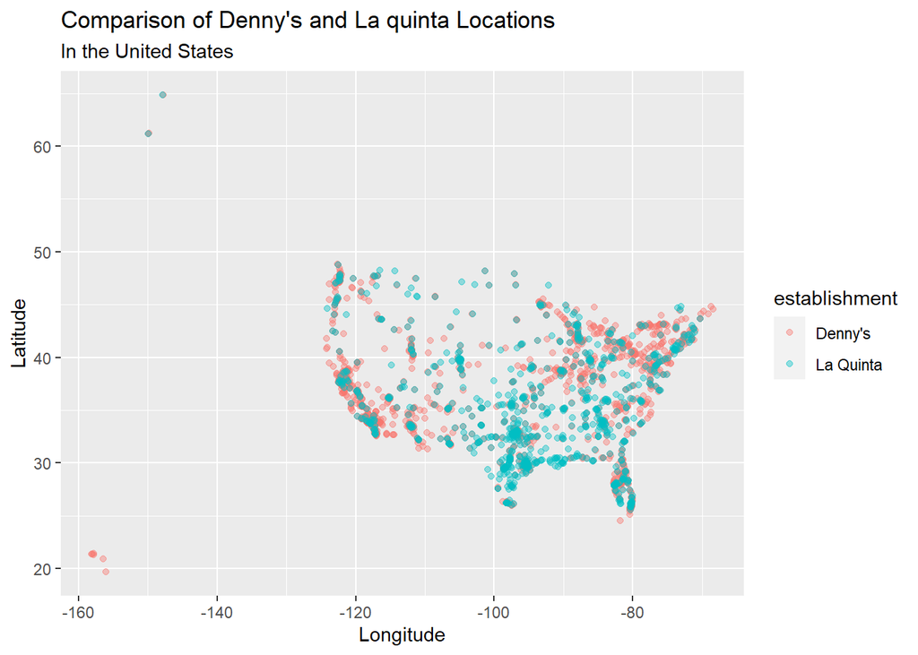

```r
ggplot(dn_lq, mapping = aes(x = longitude, y = latitude, color = establishment)) +
  geom_point(alpha=.4)+
labs(
    x = "Longitude",
    y = "Latitude",
    title = "Comparison of Denny's and La quinta Locations",
    subtitle= "In the United States"
    )
```

### Exercise 11

Filter for only locations in North Carolina and replot

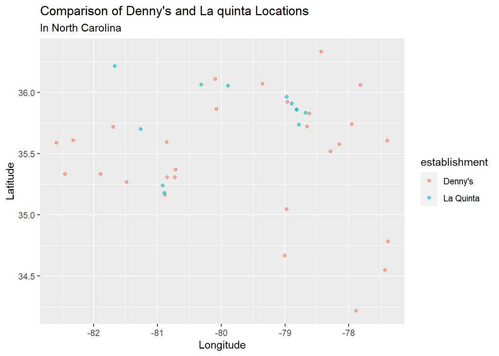

```r
dn_lq_nc <- dn_lq %>%
  filter(state=="NC")

ggplot(dn_lq_nc, mapping = aes(x = longitude, y = latitude, color = establishment)) +
  geom_point(alpha=.6)+
labs(
    x = "Longitude",
    y = "Latitude",
    title = "Comparison of Denny's and La quinta Locations",
    subtitle= "In North Carolina"
    )
```

For the most part, the La Quintas appear to be close to a Denny’s locations, so it appears that Mitch Hedgebergs joke holds true here.

### Exercise 12

Filter for only locations in Texas and re-plot

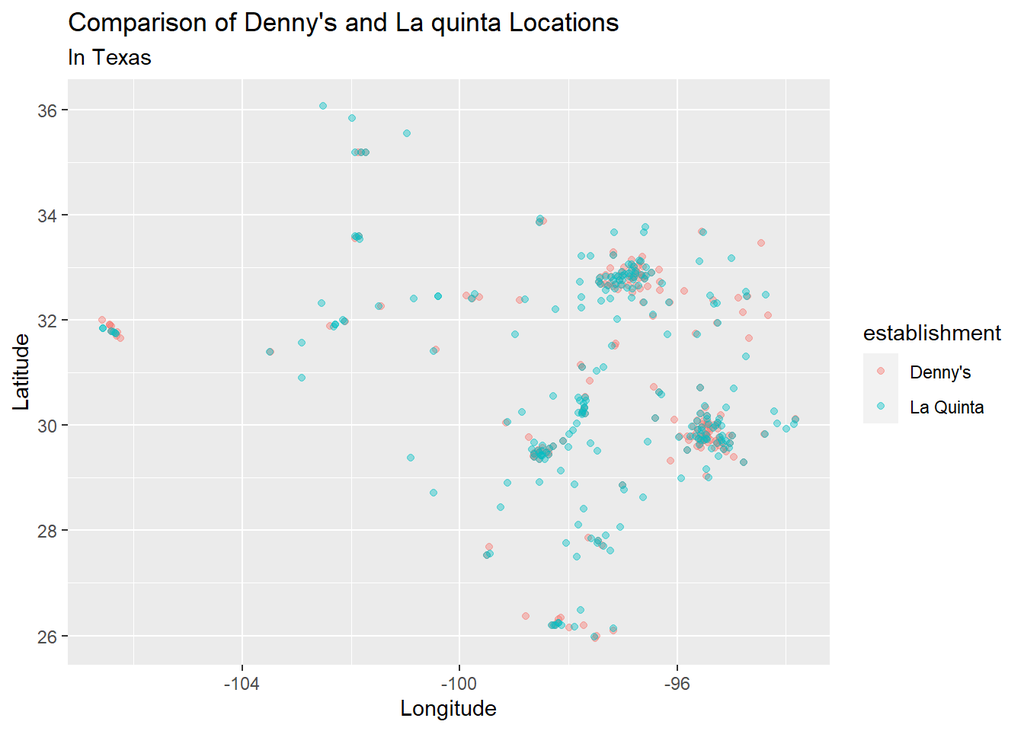

```r
dn_lq_tx <- dn_lq %>%
  filter(state=="TX")

ggplot(dn_lq_tx, mapping = aes(x = longitude, y = latitude, color = establishment)) +
  geom_point(alpha=.4)+
labs(
    x = "Longitude",
    y = "Latitude",
    title = "Comparison of Denny's and La quinta Locations",
    subtitle= "In Texas"
    )
```

The joke does not hold true here, there are many La Quinta locations that do not appear to be close to a Denny’s location.